# Project Task 1

```python
import pandas as pd
import numpy as np
import matplotlib.pylab as plt
import seaborn as sns
from scipy.stats import ttest_ind
%matplotlib inline
from datetime import date, timedelta
from mlxtend.frequent_patterns import apriori, association_rules
```

```python
df = pd.read_csv(r"....\QVI_transaction_data.csv")
```

```python
df.head(5)
```

|  | DATE | STORE_NBR | LYLTY_CARD_NBR | TXN_ID | PROD_NBR | PROD_NAME | PROD_QTY | TOT_SALES |
| --- | --- | --- | --- | --- | --- | --- | --- | --- |
| 0 | 43390 | 1 | 1000 | 1 | 5 | Natural Chip Compny SeaSalt175g | 2 | 6.0 |
| 1 | 43599 | 1 | 1307 | 348 | 66 | CCs Nacho Cheese 175g | 3 | 6.3 |
| 2 | 43605 | 1 | 1343 | 383 | 61 | Smiths Crinkle Cut Chips Chicken 170g | 2 | 2.9 |
| 3 | 43329 | 2 | 2373 | 974 | 69 | Smiths Chip Thinly S/Cream&Onion 175g | 5 | 15.0 |
| 4 | 43330 | 2 | 2426 | 1038 | 108 | Kettle Tortilla ChpsHny&Jlpno Chili 150g | 3 | 13.8 |

```python
df.describe()
```

|  | DATE | STORE_NBR | LYLTY_CARD_NBR | TXN_ID | PROD_NBR | PROD_QTY | TOT_SALES |
| --- | --- | --- | --- | --- | --- | --- | --- |
| count | 264836.000000 | 264836.00000 | 2.648360e+05 | 2.648360e+05 | 264836.000000 | 264836.000000 | 264836.000000 |
| mean | 43464.036260 | 135.08011 | 1.355495e+05 | 1.351583e+05 | 56.583157 | 1.907309 | 7.304200 |
| std | 105.389282 | 76.78418 | 8.057998e+04 | 7.813303e+04 | 32.826638 | 0.643654 | 3.083226 |
| min | 43282.000000 | 1.00000 | 1.000000e+03 | 1.000000e+00 | 1.000000 | 1.000000 | 1.500000 |
| 25% | 43373.000000 | 70.00000 | 7.002100e+04 | 6.760150e+04 | 28.000000 | 2.000000 | 5.400000 |
| 50% | 43464.000000 | 130.00000 | 1.303575e+05 | 1.351375e+05 | 56.000000 | 2.000000 | 7.400000 |
| 75% | 43555.000000 | 203.00000 | 2.030942e+05 | 2.027012e+05 | 85.000000 | 2.000000 | 9.200000 |
| max | 43646.000000 | 272.00000 | 2.373711e+06 | 2.415841e+06 | 114.000000 | 200.000000 | 650.000000 |

```python
df2 = pd.read_csv(r"....QVI_purchase_behaviour.csv")
```

```python
df2.head()
```

|  | LYLTY_CARD_NBR | LIFESTAGE | PREMIUM_CUSTOMER |
| --- | --- | --- | --- |
| 0 | 1000 | YOUNG SINGLES/COUPLES | Premium |
| 1 | 1002 | YOUNG SINGLES/COUPLES | Mainstream |
| 2 | 1003 | YOUNG FAMILIES | Budget |
| 3 | 1004 | OLDER SINGLES/COUPLES | Mainstream |
| 4 | 1005 | MIDAGE SINGLES/COUPLES | Mainstream |

```python
df2.describe()
```

|  | LYLTY_CARD_NBR |
| --- | --- |
| count | 7.263700e+04 |
| mean | 1.361859e+05 |
| std | 8.989293e+04 |
| min | 1.000000e+03 |
| 25% | 6.620200e+04 |
| 50% | 1.340400e+05 |
| 75% | 2.033750e+05 |
| max | 2.373711e+06 |

```python
df.isnull().sum()
```

```
DATE              0
STORE_NBR         0
LYLTY_CARD_NBR    0
TXN_ID            0
PROD_NBR          0
PROD_NAME         0
PROD_QTY          0
TOT_SALES         0
dtype: int64
```

```python
df2.isnull
```

```
<bound method DataFrame.isnull of        LYLTY_CARD_NBR               LIFESTAGE PREMIUM_CUSTOMER
0                1000   YOUNG SINGLES/COUPLES          Premium
1                1002   YOUNG SINGLES/COUPLES       Mainstream
2                1003          YOUNG FAMILIES           Budget
3                1004   OLDER SINGLES/COUPLES       Mainstream
4                1005  MIDAGE SINGLES/COUPLES       Mainstream
...               ...                     ...              ...
72632         2370651  MIDAGE SINGLES/COUPLES       Mainstream
72633         2370701          YOUNG FAMILIES       Mainstream
72634         2370751          YOUNG FAMILIES          Premium
72635         2370961          OLDER FAMILIES           Budget
72636         2373711   YOUNG SINGLES/COUPLES       Mainstream

[72637 rows x 3 columns]>
```

**merging df and df2**

```python
df1 = df.merge(df2, how = 'outer', on = 'LYLTY_CARD_NBR')
df1
```

|  | DATE | STORE_NBR | LYLTY_CARD_NBR | TXN_ID | PROD_NBR | PROD_NAME | PROD_QTY | TOT_SALES | LIFESTAGE | PREMIUM_CUSTOMER |
| --- | --- | --- | --- | --- | --- | --- | --- | --- | --- | --- |
| 0 | 43390 | 1 | 1000 | 1 | 5 | Natural Chip Compny SeaSalt175g | 2 | 6.0 | YOUNG SINGLES/COUPLES | Premium |
| 1 | 43359 | 1 | 1002 | 2 | 58 | Red Rock Deli Chikn&Garlic Aioli 150g | 1 | 2.7 | YOUNG SINGLES/COUPLES | Mainstream |
| 2 | 43531 | 1 | 1003 | 3 | 52 | Grain Waves Sour Cream&Chives 210G | 1 | 3.6 | YOUNG FAMILIES | Budget |
| 3 | 43532 | 1 | 1003 | 4 | 106 | Natural ChipCo Hony Soy Chckn175g | 1 | 3.0 | YOUNG FAMILIES | Budget |
| 4 | 43406 | 1 | 1004 | 5 | 96 | WW Original Stacked Chips 160g | 1 | 1.9 | OLDER SINGLES/COUPLES | Mainstream |
| ... | ... | ... | ... | ... | ... | ... | ... | ... | ... | ... |
| 264831 | 43442 | 88 | 2370701 | 240378 | 24 | Grain Waves Sweet Chilli 210g | 2 | 7.2 | YOUNG FAMILIES | Mainstream |
| 264832 | 43374 | 88 | 2370751 | 240394 | 60 | Kettle Tortilla ChpsFeta&Garlic 150g | 2 | 9.2 | YOUNG FAMILIES | Premium |
| 264833 | 43397 | 88 | 2370961 | 240480 | 70 | Tyrrells Crisps Lightly Salted 165g | 2 | 8.4 | OLDER FAMILIES | Budget |
| 264834 | 43400 | 88 | 2370961 | 240481 | 65 | Old El Paso Salsa Dip Chnky Tom Ht300g | 2 | 10.2 | OLDER FAMILIES | Budget |
| 264835 | 43448 | 88 | 2373711 | 241815 | 16 | Smiths Crinkle Chips Salt & Vinegar 330g | 2 | 11.4 | YOUNG SINGLES/COUPLES | Mainstream |

264836 rows × 10 columns

```python
df1.info()
```

```
<class 'pandas.core.frame.DataFrame'>
RangeIndex: 264836 entries, 0 to 264835
Data columns (total 10 columns):
 #   Column            Non-Null Count   Dtype
---  ------            --------------   -----
 0   DATE              264836 non-null  int64
 1   STORE_NBR         264836 non-null  int64
 2   LYLTY_CARD_NBR    264836 non-null  int64
 3   TXN_ID            264836 non-null  int64
 4   PROD_NBR          264836 non-null  int64
 5   PROD_NAME         264836 non-null  object
 6   PROD_QTY          264836 non-null  int64
 7   TOT_SALES         264836 non-null  float64
 8   LIFESTAGE         264836 non-null  object
 9   PREMIUM_CUSTOMER  264836 non-null  object
dtypes: float64(1), int64(6), object(3)
memory usage: 20.2+ MB
```

```python
df1.shape
#df.dtypes
```

```
(264836, 10)
```

**Change Date column to Datetime formate**

```python
start = date(1899, 12, 30)
new_date_format = []
for date in df1['DATE']:
    delta = timedelta(date)
    new_date_format.append(start + delta)
```

```python
df1['DATE'] = pd.to_datetime(pd.Series(new_date_format))
print(df1['DATE'].dtype)
```

```
datetime64[ns]
```

**Confirm if all product names are chips.**

```python
df1['DATE']
```

```
0        2018-10-17
1        2018-09-16
2        2019-03-07
3        2019-03-08
4        2018-11-02
            ...
264831   2018-12-08
264832   2018-10-01
264833   2018-10-24
264834   2018-10-27
264835   2018-12-14
Name: DATE, Length: 264836, dtype: datetime64[ns]
```

```python
#df1['PROD_NAME'].unique()
df1['PROD_NAME'].nunique()
```

```
114
```

```python
df1['Weight(g)'] = (
    df['PROD_NAME']
    .str.extract(r"(?i)(\d+(?:\.\d+)?)\s*[kmd]?g\b", expand=False)
    .astype(float)
)

df1['PROD_NAME'] = df['PROD_NAME'].str.rstrip()

df1
```

|  | DATE | STORE_NBR | LYLTY_CARD_NBR | TXN_ID | PROD_NBR | PROD_NAME | PROD_QTY | TOT_SALES | LIFESTAGE | PREMIUM_CUSTOMER | Weight(g) |
| --- | --- | --- | --- | --- | --- | --- | --- | --- | --- | --- | --- |
| 0 | 2018-10-17 | 1 | 1000 | 1 | 5 | Natural Chip Compny SeaSalt175g | 2 | 6.0 | YOUNG SINGLES/COUPLES | Premium | 175.0 |
| 1 | 2018-09-16 | 1 | 1002 | 2 | 58 | CCs Nacho Cheese 175g | 1 | 2.7 | YOUNG SINGLES/COUPLES | Mainstream | 175.0 |
| 2 | 2019-03-07 | 1 | 1003 | 3 | 52 | Smiths Crinkle Cut Chips Chicken 170g | 1 | 3.6 | YOUNG FAMILIES | Budget | 170.0 |
| 3 | 2019-03-08 | 1 | 1003 | 4 | 106 | Smiths Chip Thinly S/Cream&Onion 175g | 1 | 3.0 | YOUNG FAMILIES | Budget | 175.0 |
| 4 | 2018-11-02 | 1 | 1004 | 5 | 96 | Kettle Tortilla ChpsHny&Jlpno Chili 150g | 1 | 1.9 | OLDER SINGLES/COUPLES | Mainstream | 150.0 |
| ... | ... | ... | ... | ... | ... | ... | ... | ... | ... | ... | ... |
| 264831 | 2018-12-08 | 88 | 2370701 | 240378 | 24 | Kettle Sweet Chilli And Sour Cream 175g | 2 | 7.2 | YOUNG FAMILIES | Mainstream | 175.0 |
| 264832 | 2018-10-01 | 88 | 2370751 | 240394 | 60 | Tostitos Splash Of Lime 175g | 2 | 9.2 | YOUNG FAMILIES | Premium | 175.0 |
| 264833 | 2018-10-24 | 88 | 2370961 | 240480 | 70 | Doritos Mexicana 170g | 2 | 8.4 | OLDER FAMILIES | Budget | 170.0 |
| 264834 | 2018-10-27 | 88 | 2370961 | 240481 | 65 | Doritos Corn Chip Mexican Jalapeno 150g | 2 | 10.2 | OLDER FAMILIES | Budget | 150.0 |
| 264835 | 2018-12-14 | 88 | 2373711 | 241815 | 16 | Tostitos Splash Of Lime 175g | 2 | 11.4 | YOUNG SINGLES/COUPLES | Mainstream | 175.0 |

264836 rows × 11 columns

```python
df1.shape
```

```
(264836, 11)
```

```python
split_prods = df1["PROD_NAME"].str.replace(r'([0-9]+[gG])','').str.replace(r'[^\w]',' ').str.split()
```

```python
word_counts = {}
def count_words(line):
  for word in line:
    if word not in word_counts:
      word_counts[word] = 1
    else:
      word_counts[word] += 1
split_prods.apply(lambda line: count_words(line))
print(pd.Series(word_counts).sort_values(ascending = False))
```

```
175g        60561
Chips       49770
150g        41633
Kettle      41288
&           35565
            ...
Sunbites     1432
Pc           1431
NCC          1419
Garden       1419
Fries        1418
Length: 220, dtype: int64
```

```python
print(df1.describe(), '\n')
print(df.info())
```

```
                                DATE     STORE_NBR  LYLTY_CARD_NBR  \
count                         264836  264836.00000    2.648360e+05
mean   2018-12-30 00:52:12.879215360     135.08011    1.355495e+05
min              2018-07-01 00:00:00       1.00000    1.000000e+03
25%              2018-09-30 00:00:00      70.00000    7.002100e+04
50%              2018-12-30 00:00:00     130.00000    1.303575e+05
75%              2019-03-31 00:00:00     203.00000    2.030942e+05
max              2019-06-30 00:00:00     272.00000    2.373711e+06
std                              NaN      76.78418    8.057998e+04

             TXN_ID       PROD_NBR       PROD_QTY      TOT_SALES  \
count  2.648360e+05  264836.000000  264836.000000  264836.000000
mean   1.351583e+05      56.583157       1.907309       7.304200
min    1.000000e+00       1.000000       1.000000       1.500000
25%    6.760150e+04      28.000000       2.000000       5.400000
50%    1.351375e+05      56.000000       2.000000       7.400000
75%    2.027012e+05      85.000000       2.000000       9.200000
max    2.415841e+06     114.000000     200.000000     650.000000
std    7.813303e+04      32.826638       0.643654       3.083226

           Weight(g)
count  264836.000000
mean      182.427004
min        70.000000
25%       150.000000
50%       170.000000
75%       175.000000
max       380.000000
std        64.327196

<class 'pandas.core.frame.DataFrame'>
RangeIndex: 264836 entries, 0 to 264835
Data columns (total 8 columns):
 #   Column          Non-Null Count   Dtype
---  ------          --------------   -----
 0   DATE            264836 non-null  int64
 1   STORE_NBR       264836 non-null  int64
 2   LYLTY_CARD_NBR  264836 non-null  int64
 3   TXN_ID          264836 non-null  int64
 4   PROD_NBR        264836 non-null  int64
 5   PROD_NAME       264836 non-null  object
 6   PROD_QTY        264836 non-null  int64
 7   TOT_SALES       264836 non-null  float64
dtypes: float64(1), int64(6), object(1)
memory usage: 16.2+ MB
None
```

```python
df['PROD_QTY'].value_counts(bins=4).sort_index()
```

```
(0.8, 50.75]       264834
(50.75, 100.5]          0
(100.5, 150.25]         0
(150.25, 200.0]         2
Name: count, dtype: int64
```

**PROD_QTY values above 50.75**

```python
df1['DATE']
```

```
0        2018-10-17
1        2018-09-16
2        2019-03-07
3        2019-03-08
4        2018-11-02
            ...
264831   2018-12-08
264832   2018-10-01
264833   2018-10-24
264834   2018-10-27
264835   2018-12-14
Name: DATE, Length: 264836, dtype: datetime64[ns]
```

```python
df1.sort_values(by='PROD_QTY', ascending=False).head()
```

|  | DATE | STORE_NBR | LYLTY_CARD_NBR | TXN_ID | PROD_NBR | PROD_NAME | PROD_QTY | TOT_SALES | LIFESTAGE | PREMIUM_CUSTOMER | Weight(g) |
| --- | --- | --- | --- | --- | --- | --- | --- | --- | --- | --- | --- |
| 221626 | 2019-05-20 | 226 | 226000 | 226210 | 4 | RRD Chilli& Coconut 150g | 200 | 650.0 | OLDER FAMILIES | Premium | 150.0 |
| 221625 | 2018-08-19 | 226 | 226000 | 226201 | 4 | Natural Chip Co Tmato Hrb&Spce 175g | 200 | 650.0 | OLDER FAMILIES | Premium | 175.0 |
| 145041 | 2019-05-20 | 148 | 148238 | 148046 | 87 | Dorito Corn Chp Supreme 380g | 5 | 19.0 | OLDER SINGLES/COUPLES | Mainstream | 380.0 |
| 89729 | 2018-08-16 | 93 | 93152 | 91631 | 46 | Grain Waves Sweet Chilli 210g | 5 | 27.0 | RETIREES | Premium | 210.0 |
| 76734 | 2018-08-15 | 80 | 80018 | 78356 | 26 | Pringles Barbeque 134g | 5 | 18.5 | MIDAGE SINGLES/COUPLES | Mainstream | 134.0 |

```python
df1.shape
```

```
(264836, 11)
```

**Two outliers of value 200 in PROD_QTY will be removed. Both entries are by the same customers** ss

```python
df1 = df1[df1['PROD_QTY'] <6]
```

```python
#index_of_outliers =
len(df1[df['LYLTY_CARD_NBR'] ==226000])
```

```
2
```

```python
df1 = df.drop(index_of_outliers)
print('OUTLIERS REMOVED!')
```

[output not shown]

```python
df1['DATE'].nunique()
```

```
364
```

**There are 365 days in a year but in the DATE column there are only 364 unique values so one is missing**

```python
pd.date_range(start=df1['DATE'].min(), end=df1['DATE'].max()).difference(df1['DATE'])
```

```
DatetimeIndex(['2018-12-25'], dtype='datetime64[ns]', freq='D')
```

**The difference method helps to see that '2018-12-25' was the missing date**

```python
check_null_date = pd.merge(pd.Series(pd.date_range(start=df1["DATE"].min(), end = df1["DATE"].max()), name="DATE"), df1, on = "DATE", how = "left")
```

```
<function matplotlib.pyplot.show(close=None, block=None)>
```

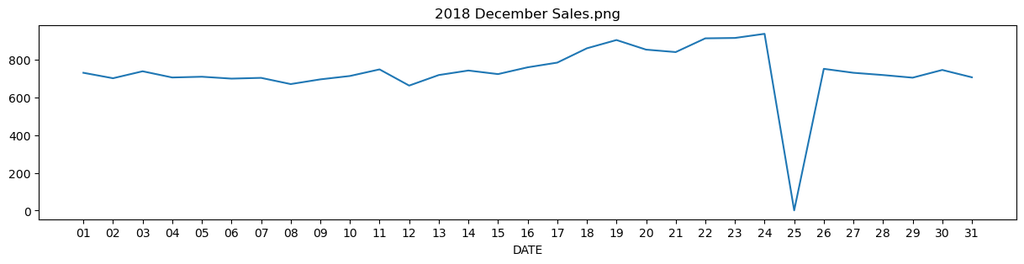

```python
trans_by_date = check_null_date['DATE'].value_counts()
start_date = pd.to_datetime('2018-12-01')
end_date = pd.to_datetime('2019-01-01')
dec = trans_by_date[(trans_by_date.index >= start_date) & (trans_by_date.index < end_date)].sort_index()
dec.index = dec.index.strftime('%d')
ax = dec.plot(figsize = (15,3))
ax.set_xticks(np.arange(len(dec)))
ax.set_xticklabels(dec.index)
plt.title("2018 December Sales.png") #bbox_inches= 'tight')
plt.show
```

```python
check_null_date['DATE'].value_counts().sort_values().head()
```

```
DATE
2018-12-25      1
2018-11-25    648
2018-10-18    658
2019-06-13    659
2019-06-24    662
Name: count, dtype: int64
```

**25th December was the day with no transaction because the store was closed down. This is normal**

***Explore Packet Sizes***

```
count    264834.000000
mean        182.427154
std          64.327407
min          70.000000
25%         150.000000
50%         170.000000
75%         175.000000
max         380.000000
Name: Weight(g), dtype: float64
```

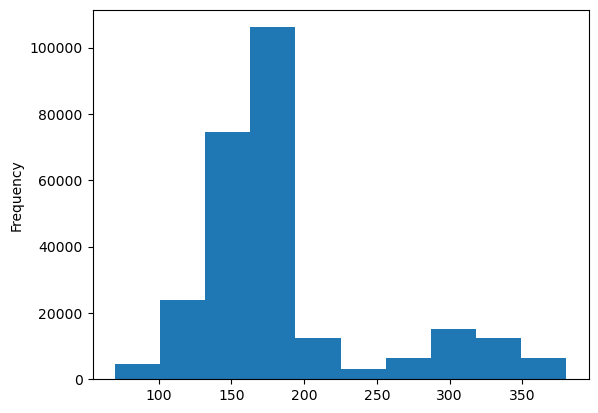

```python
print(df1['Weight(g)'].describe())
df1['Weight(g)'].plot.hist()
```

```python
df1['Weight(g)'].value_counts().sort_index()
```

```
Weight(g)
70.0      1507
90.0      3008
110.0    22387
125.0     1454
134.0    25102
135.0     3257
150.0    43130
160.0     2970
165.0    15297
170.0    19983
175.0    66389
180.0     1468
190.0     2995
200.0     4473
210.0     6272
220.0     1564
250.0     3169
270.0     6285
300.0    15166
330.0    12540
380.0     6418
Name: count, dtype: int64
```

```python
df1['PROD_NAME'].str.split().str[0].value_counts().sort_index()
```

```
PROD_NAME
Burger         1564
CCs            4551
Cheetos        2927
Cheezels       4603
Cobs           9693
Dorito         3185
Doritos       24962
French         1418
Grain          6272
GrnWves        1468
Infuzions     11057
Infzns         3144
Kettle        41288
NCC            1419
Natural        6049
Old            9324
Pringles      25102
RRD           11893
Red            5885
Smith          2963
Smiths        28860
Snbts          1576
Sunbites       1432
Thins         14075
Tostitos       9471
Twisties       9454
Tyrrells       6442
WW            10320
Woolworths     4437
Name: count, dtype: int64
```

Some product names are written in more than one way. Example : Dorito and Doritos, Grains and GrnWves, Infusions and Ifzns, Natural and NCC, Red and RRD, Smith and Smiths and Snbts and Sunbites.

```python
df1['split_prod_name'] = df1['PROD_NAME'].str.split()

df1['Cleaned_Brand_Names'] = df1['split_prod_name'].apply(lambda x: x[0] if len(x) > 0 else '')

 #Drop the intermediate column if no longer needed
df1.drop(columns=['split_prod_name'], inplace=True)
```

```python
def clean_brand_names(line):
    brand = line['Cleaned_Brand_Names']
    if brand == "Dorito":
        return "Doritos"
    elif brand == "GrnWves" or brand == "Grain":
        return "Grain Waves"
    elif brand == "Infzns":
        return "Infuzions"
    elif brand == "Natural" or brand == "NCC":
        return "Natural Chip Co"
    elif brand == "Red":
        return "RRD"
    elif brand == "Smith":
        return "Smiths"
    elif brand == "Snbts":
        return "Sunbites"
    elif brand == "WW":
        return "Woolworths"
    else:
        return brand
```

```python
df1['Cleaned_Brand_Names'] = df1.apply(lambda line: clean_brand_names(line), axis=1)
```

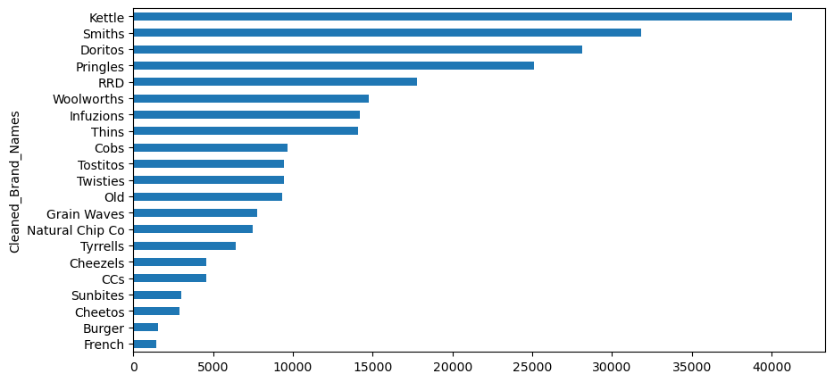

```python
df1['Cleaned_Brand_Names'].value_counts(ascending=True).plot.barh(figsize=(10, 5))
```

```python
df1.isnull().sum()
```

```
DATE                   0
STORE_NBR              0
LYLTY_CARD_NBR         0
TXN_ID                 0
PROD_NBR               0
PROD_NAME              0
PROD_QTY               0
TOT_SALES              0
LIFESTAGE              0
PREMIUM_CUSTOMER       0
Weight(g)              0
Cleaned_Brand_Names    0
dtype: int64
```

```python
grouped_sales = pd.DataFrame(df1.groupby(['LIFESTAGE', 'PREMIUM_CUSTOMER'])["TOT_SALES"].agg(["sum", "mean"]))
grouped_sales.sort_values(ascending=False, by='sum')
```

| LIFESTAGE | PREMIUM_CUSTOMER | sum | mean |
| --- | --- | --- | --- |
| OLDER FAMILIES | Budget | 168363.25 | 7.269570 |
| YOUNG SINGLES/COUPLES | Mainstream | 157621.60 | 7.558339 |
| RETIREES | Mainstream | 155677.05 | 7.252262 |
| YOUNG FAMILIES | Budget | 139345.85 | 7.287201 |
| OLDER SINGLES/COUPLES | Budget | 136769.80 | 7.430315 |
|  | Mainstream | 133393.80 | 7.282116 |
|  | Premium | 132263.15 | 7.449766 |
| RETIREES | Budget | 113147.80 | 7.443445 |
| OLDER FAMILIES | Mainstream | 103445.55 | 7.262395 |
| RETIREES | Premium | 97646.05 | 7.456174 |
| YOUNG FAMILIES | Mainstream | 92788.75 | 7.189025 |
| MIDAGE SINGLES/COUPLES | Mainstream | 90803.85 | 7.647284 |
| YOUNG FAMILIES | Premium | 84025.50 | 7.266756 |
| OLDER FAMILIES | Premium | 80658.40 | 7.208079 |
| YOUNG SINGLES/COUPLES | Budget | 61141.60 | 6.615624 |
| MIDAGE SINGLES/COUPLES | Premium | 58432.65 | 7.112056 |
| YOUNG SINGLES/COUPLES | Premium | 41642.10 | 6.629852 |
| MIDAGE SINGLES/COUPLES | Budget | 35514.80 | 7.074661 |
| NEW FAMILIES | Budget | 21928.45 | 7.297321 |
|  | Mainstream | 17013.90 | 7.317806 |
|  | Premium | 11491.10 | 7.231655 |

```python
grouped_sales['sum'].sum()
```

```
1933115.0000000002
```

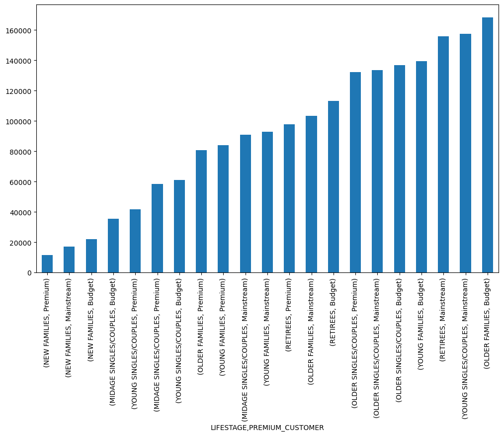

```python
grouped_sales['sum'].sort_values().plot.bar(figsize=(12,7))
```

[figure not shown]

```python
 # Values of each group
bars1 = grouped_sales[grouped_sales.index.get_level_values("PREMIUM_CUSTOMER") == "Budget"]["sum"]
bars2 = grouped_sales[grouped_sales.index.get_level_values("PREMIUM_CUSTOMER") == "Mainstream"]["sum"]
bars3 = grouped_sales[grouped_sales.index.get_level_values("PREMIUM_CUSTOMER") == "Premium"]["sum"]

bars1_text = (bars1 / sum(grouped_sales["sum"])).apply("{:.1%}".format)
bars2_text = (bars2 / sum(grouped_sales["sum"])).apply("{:.1%}".format)
bars3_text = (bars3 / sum(grouped_sales["sum"])).apply("{:.1%}".format)

#Names of group and bar width
names = grouped_sales.index.get_level_values('LIFESTAGE').unique()

# the position of the bar on the axis
r = np.arange(len(names))

plt.figure(figsize=(13,5))

# Create brown bars
budget_bar = plt.barh(r, bars1, edgecolor='grey', height=1, label='Budget')

# Create green bars(middle), on top of the first ones
mains_bar = plt.barh(r, bars2, left=bars1, edgecolor='grey', height=1, label="Mainstream")
# Create green bars (top)
tmp_bar = np.add(bars1, bars2)
prem_bar = plt.barh(r, bars3, left=bars2, edgecolor='grey', height=1, label="Premium")

for i in range(7):
    budget_width = budget_bar[i].get_width()
    budget_main_width = budget_width + mains_bar[i].get_width()
    plt.text(budget_width/2, i, bars1_text[i], va='center', ha='center', size=8)
    plt.text(budget_width + mains_bar[i].get_width()/2, i, bars2_text[i], va='center', ha='center', size=8)
    plt.text(budget_main_width + prem_bar[i].get_width()/2, i, bars3_text[i], va='center', ha='center', size=8)

# Custom X axis
plt.yticks(r, names)
plt.ylabel("LIFESTAGE")
plt.xlabel("TOTAL SALES")
plt.legend(loc='center left', bbox_to_anchor=(1.0, 0.5))

plt.title("Total Sales per Lifestage")

plt.savefig("lifestage_sales.png", bbox_inches="tight")

# Show graphic
plt.show()
```

```python
stage_agg_prem = df1.groupby('LIFESTAGE')['PREMIUM_CUSTOMER'].agg(pd.Series.mode).sort_values()
#stage_agg_prem = df1.groupby("LIFESTAGE")["PREMIUM_CUSTOMER"].agg(pd.Series.mode).sort_values()
print('Top contributor per LIFESTAGE by PREMIUM category')
print(stage_agg_prem)
```

```
Top contributor per LIFESTAGE by PREMIUM category
LIFESTAGE
NEW FAMILIES                  Budget
OLDER FAMILIES                Budget
OLDER SINGLES/COUPLES         Budget
YOUNG FAMILIES                Budget
MIDAGE SINGLES/COUPLES    Mainstream
RETIREES                  Mainstream
YOUNG SINGLES/COUPLES     Mainstream
Name: PREMIUM_CUSTOMER, dtype: object
```

```python
unique_cust = df1.groupby(['LIFESTAGE', 'PREMIUM_CUSTOMER'])['LYLTY_CARD_NBR'].nunique().sort_values(ascending=False)
pd.DataFrame(unique_cust)
```

| LIFESTAGE | PREMIUM_CUSTOMER | LYLTY_CARD_NBR |
| --- | --- | --- |
| YOUNG SINGLES/COUPLES | Mainstream | 8088 |
| RETIREES | Mainstream | 6479 |
| OLDER SINGLES/COUPLES | Mainstream | 4930 |
|  | Budget | 4929 |
|  | Premium | 4750 |
| OLDER FAMILIES | Budget | 4675 |
| RETIREES | Budget | 4454 |
| YOUNG FAMILIES | Budget | 4017 |
| RETIREES | Premium | 3872 |
| YOUNG SINGLES/COUPLES | Budget | 3779 |
| MIDAGE SINGLES/COUPLES | Mainstream | 3340 |
| OLDER FAMILIES | Mainstream | 2831 |
| YOUNG FAMILIES | Mainstream | 2728 |
| YOUNG SINGLES/COUPLES | Premium | 2574 |
| YOUNG FAMILIES | Premium | 2433 |
| MIDAGE SINGLES/COUPLES | Premium | 2431 |
| OLDER FAMILIES | Premium | 2273 |
| MIDAGE SINGLES/COUPLES | Budget | 1504 |
| NEW FAMILIES | Budget | 1112 |
|  | Mainstream | 849 |
|  | Premium | 588 |

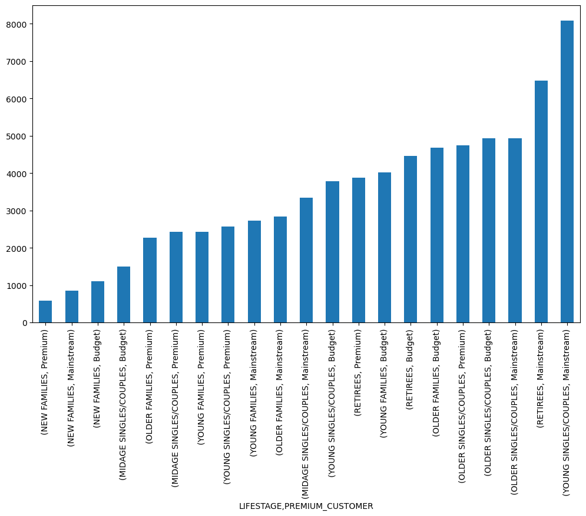

```python
unique_cust.sort_values().plot.bar(figsize=(12,7))
```

[figure not shown]

```python
# Values of each group
ncust_bars1 = unique_cust[unique_cust.index.get_level_values("PREMIUM_CUSTOMER") == "Budget"]
ncust_bars2 = unique_cust[unique_cust.index.get_level_values("PREMIUM_CUSTOMER") == "Mainstream"]
ncust_bars3 = unique_cust[unique_cust.index.get_level_values("PREMIUM_CUSTOMER") == "Premium"]

ncust_bars1_text = (ncust_bars1 / sum(unique_cust)).apply("{:.1%}".format)
ncust_bars2_text = (ncust_bars2 / sum(unique_cust)).apply("{:.1%}".format)
ncust_bars3_text = (ncust_bars3 / sum(unique_cust)).apply("{:.1%}".format)

# # Names of group and bar width
#names = unique_cust.index.get_level_values("LIFESTAGE").unique()

# # The position of the bars on the x-axis
#r = np.arange(len(names))

plt.figure(figsize=(13,5))

# # Create brown bars
budget_bar = plt.barh(r, ncust_bars1, edgecolor='grey', height=1, label="Budget")
# # Create green bars (middle), on top of the firs ones
mains_bar = plt.barh(r, ncust_bars2, left=ncust_bars1, edgecolor='grey', height=1, label="Mainstream")
# # Create green bars (top)
prem_bar = plt.barh(r, ncust_bars3, left=ncust_bars2, edgecolor='grey', height=1, label="Premium")

for i in range(7):
    budget_width = budget_bar[i].get_width()
    budget_main_width = budget_width + mains_bar[i].get_width()
    plt.text(budget_width/2, i, ncust_bars1_text[i], va='center', ha='center', size=8)
    plt.text(budget_width + mains_bar[i].get_width()/2, i, ncust_bars2_text[i], va='center', ha='center', size=8)
    plt.text(budget_main_width + prem_bar[i].get_width()/2, i, ncust_bars3_text[i], va='center', ha='center', size=8)

# Custom X axis
plt.yticks(r, names)
plt.ylabel("LIFESTAGE")
plt.xlabel("UNIQUE CUSTOMERS")
plt.legend(loc='center left', bbox_to_anchor=(1.0, 0.5))

plt.title("Unique Customers per Lifestage")

plt.savefig("lifestage_customers.png") # bbox_inches="tight")

# # Show graphic
plt.show()
```

The high sales amount by segment "Young Singles/Couples - Mainstream" and "Retirees - Mainstream" are due to their large number of unique customers, but not for the "Older - Budget" segment. Next we'll explore if the "Older - Budget" segment has:

High Frequency of Purchase and, Average Sales per Customer compared to the other segment.

```python
freq_per_cust = df1.groupby(['LYLTY_CARD_NBR', 'LIFESTAGE', 'PREMIUM_CUSTOMER']).count()["DATE"]
freq_per_cust.groupby(["LIFESTAGE", "PREMIUM_CUSTOMER"]).agg(["mean", "count"]).sort_values(ascending=False, by="mean")
```

| LIFESTAGE | PREMIUM_CUSTOMER | mean | count |
| --- | --- | --- | --- |
| OLDER FAMILIES | Mainstream | 5.031438 | 2831 |
|  | Budget | 4.954011 | 4675 |
|  | Premium | 4.923009 | 2273 |
| YOUNG FAMILIES | Budget | 4.760269 | 4017 |
|  | Premium | 4.752569 | 2433 |
|  | Mainstream | 4.731305 | 2728 |
| OLDER SINGLES/COUPLES | Premium | 3.737684 | 4750 |
|  | Budget | 3.734429 | 4929 |
|  | Mainstream | 3.715619 | 4930 |
| MIDAGE SINGLES/COUPLES | Mainstream | 3.555090 | 3340 |
| RETIREES | Budget | 3.412887 | 4454 |
|  | Premium | 3.382231 | 3872 |
| MIDAGE SINGLES/COUPLES | Premium | 3.379679 | 2431 |
|  | Budget | 3.337766 | 1504 |
| RETIREES | Mainstream | 3.313166 | 6479 |
| NEW FAMILIES | Mainstream | 2.738516 | 849 |
|  | Premium | 2.702381 | 588 |
|  | Budget | 2.702338 | 1112 |
| YOUNG SINGLES/COUPLES | Mainstream | 2.578388 | 8088 |
|  | Budget | 2.445621 | 3779 |
|  | Premium | 2.440171 | 2574 |

The above table describes the "Average frequency of Purchase per segment" and "Unique customer per segment". The top three most frequent purchase is contributed by the "Older Families" lifestage segment. We can see now that the "Older - Budget" segment contributes to high sales partly because of the combination of:

High Frequency of Purchase and, Fairly high unique number of customer in the segment

```python
grouped_sales.sort_values(ascending=False, by='mean')
```

| LIFESTAGE | PREMIUM_CUSTOMER | sum | mean |
| --- | --- | --- | --- |
| MIDAGE SINGLES/COUPLES | Mainstream | 90803.85 | 7.647284 |
| YOUNG SINGLES/COUPLES | Mainstream | 157621.60 | 7.558339 |
| RETIREES | Premium | 97646.05 | 7.456174 |
| OLDER SINGLES/COUPLES | Premium | 132263.15 | 7.449766 |
| RETIREES | Budget | 113147.80 | 7.443445 |
| OLDER SINGLES/COUPLES | Budget | 136769.80 | 7.430315 |
| NEW FAMILIES | Mainstream | 17013.90 | 7.317806 |
|  | Budget | 21928.45 | 7.297321 |
| YOUNG FAMILIES | Budget | 139345.85 | 7.287201 |
| OLDER SINGLES/COUPLES | Mainstream | 133393.80 | 7.282116 |
| OLDER FAMILIES | Budget | 168363.25 | 7.269570 |
| YOUNG FAMILIES | Premium | 84025.50 | 7.266756 |
| OLDER FAMILIES | Mainstream | 103445.55 | 7.262395 |
| RETIREES | Mainstream | 155677.05 | 7.252262 |
| NEW FAMILIES | Premium | 11491.10 | 7.231655 |
| OLDER FAMILIES | Premium | 80658.40 | 7.208079 |
| YOUNG FAMILIES | Mainstream | 92788.75 | 7.189025 |
| MIDAGE SINGLES/COUPLES | Premium | 58432.65 | 7.112056 |
|  | Budget | 35514.80 | 7.074661 |
| YOUNG SINGLES/COUPLES | Premium | 41642.10 | 6.629852 |
|  | Budget | 61141.60 | 6.615624 |

“The Midage and Young ‘Singles/Couples’ exhibit the highest average spending per purchase. Although the difference between their Mainstream and Non-Mainstream groups appears small (7.6 vs. 6.6), we will investigate whether this difference is statistically significant

```python
mainstream = df1['PREMIUM_CUSTOMER'] == 'Mainstream'
young_midage = (df1['LIFESTAGE'] == 'MIDAGE SINGLES/COUPLES') | (df1["LIFESTAGE"] == "YOUNG SINGLES/COUPLES")

budget_premium = (df1['PREMIUM_CUSTOMER'] == 'budget')| (df1["PREMIUM_CUSTOMER"] == "Premium")

a = df1[young_midage & mainstream]['TOT_SALES']
b = df1[young_midage & budget_premium]['TOT_SALES']
stat, pval = ttest_ind(a.values, b.values, equal_var=False)

print(pval)
pval< 0.0000001
```

```
1.972411468374434e-153
```

```
True
```

**Next, let's examine what brand of chips the top 3 segments contributing to Total Sales are buying.**

```python
df1.groupby(["LIFESTAGE", "PREMIUM_CUSTOMER"])["Cleaned_Brand_Names"].agg(pd.Series.mode).sort_values()
```

```
LIFESTAGE               PREMIUM_CUSTOMER
MIDAGE SINGLES/COUPLES  Budget              Kettle
YOUNG SINGLES/COUPLES   Budget              Kettle
YOUNG FAMILIES          Premium             Kettle
                        Mainstream          Kettle
                        Budget              Kettle
RETIREES                Premium             Kettle
                        Mainstream          Kettle
                        Budget              Kettle
OLDER SINGLES/COUPLES   Premium             Kettle
YOUNG SINGLES/COUPLES   Mainstream          Kettle
OLDER SINGLES/COUPLES   Mainstream          Kettle
OLDER FAMILIES          Premium             Kettle
                        Mainstream          Kettle
                        Budget              Kettle
NEW FAMILIES            Premium             Kettle
                        Mainstream          Kettle
                        Budget              Kettle
MIDAGE SINGLES/COUPLES  Premium             Kettle
                        Mainstream          Kettle
OLDER SINGLES/COUPLES   Budget              Kettle
YOUNG SINGLES/COUPLES   Premium             Kettle
Name: Cleaned_Brand_Names, dtype: object
```

```
==== YOUNG SINGLES/COUPLES - Premium ====
Cleaned_Brand_Names
Kettle     963
Smiths     763
Doritos    674
Name: count, dtype: int64
==== YOUNG SINGLES/COUPLES - Mainstream ====
Cleaned_Brand_Names
Kettle     3312
Smiths     2551
Doritos    2202
Name: count, dtype: int64
==== YOUNG SINGLES/COUPLES - Budget ====
Cleaned_Brand_Names
Kettle     1396
Smiths     1121
Doritos     979
Name: count, dtype: int64
==== YOUNG FAMILIES - Premium ====
Cleaned_Brand_Names
Kettle     1737
Smiths     1388
Doritos    1238
Name: count, dtype: int64
==== YOUNG FAMILIES - Mainstream ====
Cleaned_Brand_Names
Kettle     2082
Smiths     1498
Doritos    1370
Name: count, dtype: int64
==== YOUNG FAMILIES - Budget ====
Cleaned_Brand_Names
Kettle     2978
Smiths     2289
Doritos    2088
Name: count, dtype: int64
==== OLDER SINGLES/COUPLES - Premium ====
Cleaned_Brand_Names
Kettle     2725
Smiths     2130
```

[output cut: 71 more lines]

```
Smiths     1578
Doritos    1389
Name: count, dtype: int64
==== RETIREES - Mainstream ====
Cleaned_Brand_Names
Kettle     3352
Smiths     2577
Doritos    2303
Name: count, dtype: int64
==== RETIREES - Budget ====
Cleaned_Brand_Names
Kettle     2392
Smiths     1886
Doritos    1534
Name: count, dtype: int64
```

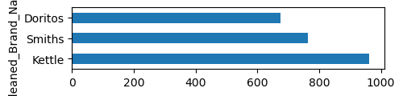

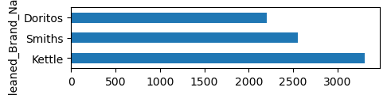

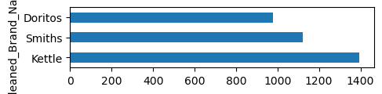

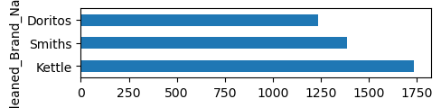

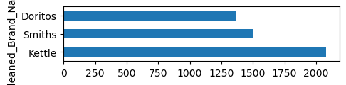

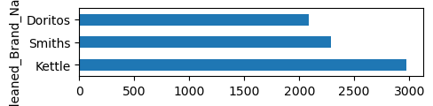

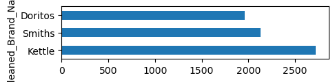

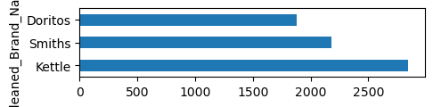

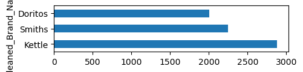

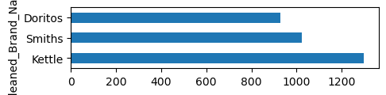

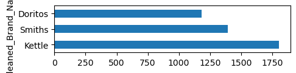

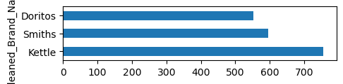

[9 more figures not shown]

```python
for stage in df1['LIFESTAGE'].unique():
    for prem in df1['PREMIUM_CUSTOMER'].unique():
        print('====', stage, '-', prem,'====')
        summary = df1[(df1['LIFESTAGE'] == stage) & (df1["PREMIUM_CUSTOMER"] == prem)]["Cleaned_Brand_Names"].value_counts().head(3)
        print(summary)
        plt.figure()
        summary.plot.barh(figsize=(5,1))
        plt.show
```

Kettle: The most purchased brand across all segments.

```python
temp = df1.reset_index().rename(columns ={'index': 'transaction'})
temp['Segment'] = temp['LIFESTAGE'] + '-' + temp['PREMIUM_CUSTOMER']
segment_brand_encode = pd.concat([pd.get_dummies(temp['Segment']), pd.get_dummies(temp["Cleaned_Brand_Names"])], axis=1)

frequent_sets = apriori(segment_brand_encode, min_support=0.01, use_colnames=True)
rules = association_rules(frequent_sets, metric='lift', min_threshold=1)

set_temp = temp['Segment'].unique()
rules[rules['antecedents'].apply(lambda x: list(x)).apply(lambda x: x in set_temp)]
```

|  | antecedents | consequents | antecedent support | consequent support | support | confidence | lift | leverage | conviction | zhangs_metric |
| --- | --- | --- | --- | --- | --- | --- | --- | --- | --- | --- |
| 0 | (OLDER FAMILIES-Budget) | (Kettle) | 0.087451 | 0.155901 | 0.013669 | 0.156304 | 1.002582 | 0.000035 | 1.000477 | 0.002822 |
| 3 | (OLDER SINGLES/COUPLES-Budget) | (Kettle) | 0.069504 | 0.155901 | 0.010886 | 0.156625 | 1.004642 | 0.000050 | 1.000858 | 0.004966 |
| 4 | (RETIREES-Mainstream) | (Kettle) | 0.081055 | 0.155901 | 0.012657 | 0.156154 | 1.001620 | 0.000020 | 1.000299 | 0.001760 |
| 6 | (YOUNG SINGLES/COUPLES-Mainstream) | (Kettle) | 0.078744 | 0.155901 | 0.012506 | 0.158818 | 1.018711 | 0.000230 | 1.003468 | 0.019937 |

Next, we'll find out the pack size preferences of different segments

```python
df1
```

|  | DATE | STORE_NBR | LYLTY_CARD_NBR | TXN_ID | PROD_NBR | PROD_NAME | PROD_QTY | TOT_SALES | LIFESTAGE | PREMIUM_CUSTOMER | Weight(g) | Cleaned_Brand_Names |
| --- | --- | --- | --- | --- | --- | --- | --- | --- | --- | --- | --- | --- |
| 0 | 2018-10-17 | 1 | 1000 | 1 | 5 | Natural Chip Compny SeaSalt175g | 2 | 6.0 | YOUNG SINGLES/COUPLES | Premium | 175.0 | Natural Chip Co |
| 1 | 2018-09-16 | 1 | 1002 | 2 | 58 | CCs Nacho Cheese 175g | 1 | 2.7 | YOUNG SINGLES/COUPLES | Mainstream | 175.0 | CCs |
| 2 | 2019-03-07 | 1 | 1003 | 3 | 52 | Smiths Crinkle Cut Chips Chicken 170g | 1 | 3.6 | YOUNG FAMILIES | Budget | 170.0 | Smiths |
| 3 | 2019-03-08 | 1 | 1003 | 4 | 106 | Smiths Chip Thinly S/Cream&Onion 175g | 1 | 3.0 | YOUNG FAMILIES | Budget | 175.0 | Smiths |
| 4 | 2018-11-02 | 1 | 1004 | 5 | 96 | Kettle Tortilla ChpsHny&Jlpno Chili 150g | 1 | 1.9 | OLDER SINGLES/COUPLES | Mainstream | 150.0 | Kettle |
| ... | ... | ... | ... | ... | ... | ... | ... | ... | ... | ... | ... | ... |
| 264831 | 2018-12-08 | 88 | 2370701 | 240378 | 24 | Kettle Sweet Chilli And Sour Cream 175g | 2 | 7.2 | YOUNG FAMILIES | Mainstream | 175.0 | Kettle |
| 264832 | 2018-10-01 | 88 | 2370751 | 240394 | 60 | Tostitos Splash Of Lime 175g | 2 | 9.2 | YOUNG FAMILIES | Premium | 175.0 | Tostitos |
| 264833 | 2018-10-24 | 88 | 2370961 | 240480 | 70 | Doritos Mexicana 170g | 2 | 8.4 | OLDER FAMILIES | Budget | 170.0 | Doritos |
| 264834 | 2018-10-27 | 88 | 2370961 | 240481 | 65 | Doritos Corn Chip Mexican Jalapeno 150g | 2 | 10.2 | OLDER FAMILIES | Budget | 150.0 | Doritos |
| 264835 | 2018-12-14 | 88 | 2373711 | 241815 | 16 | Tostitos Splash Of Lime 175g | 2 | 11.4 | YOUNG SINGLES/COUPLES | Mainstream | 175.0 | Tostitos |

264834 rows × 12 columns

```python
pack_sizes = df1['PROD_NAME'].str.extract(r'(\d+)g', expand=False).astype(float)

pack_sizes = pack_sizes.rename('Pack_Size')

merged_pack = pd.concat([df1, pack_sizes], axis=1)
```

```
========== YOUNG SINGLES/COUPLES - Premium ==========
Pack_Size
134.0     600
150.0     952
175.0    1509
Name: count, dtype: int64
```

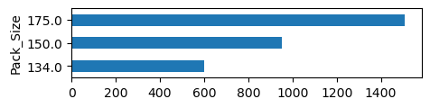

```
========== YOUNG SINGLES/COUPLES - Mainstream ==========
Pack_Size
134.0    2000
150.0    3327
175.0    5023
Name: count, dtype: int64
```

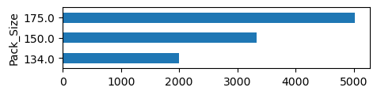

```
========== YOUNG SINGLES/COUPLES - Budget ==========
Pack_Size
134.0     867
150.0    1430
175.0    2262
Name: count, dtype: int64
```

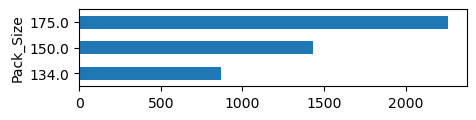

```
========== YOUNG FAMILIES - Premium ==========
Pack_Size
134.0    1059
150.0    1821
175.0    2786
Name: count, dtype: int64
```

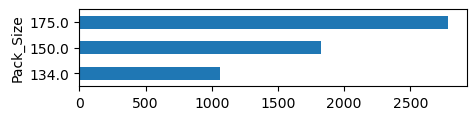

```
========== YOUNG FAMILIES - Mainstream ==========
Pack_Size
134.0    1247
150.0    1984
175.0    3210
Name: count, dtype: int64
```

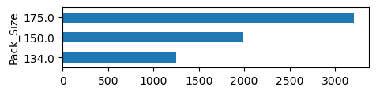

```
========== YOUNG FAMILIES - Budget ==========
Pack_Size
134.0    1831
150.0    3053
175.0    4648
Name: count, dtype: int64
```

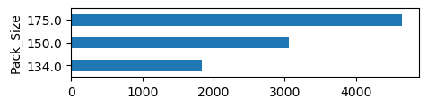

```
========== OLDER SINGLES/COUPLES - Premium ==========
Pack_Size
134.0    1634
150.0    2803
175.0    4398
Name: count, dtype: int64
```

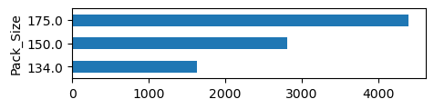

```
========== OLDER SINGLES/COUPLES - Mainstream ==========
Pack_Size
134.0    1768
150.0    2838
175.0    4550
Name: count, dtype: int64
```

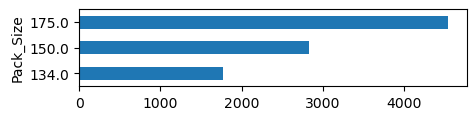

```
========== OLDER SINGLES/COUPLES - Budget ==========
Pack_Size
134.0    1738
150.0    2994
175.0    4529
Name: count, dtype: int64
```

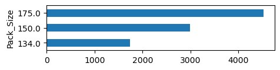

```
========== MIDAGE SINGLES/COUPLES - Premium ==========
Pack_Size
134.0     729
150.0    1267
175.0    2002
Name: count, dtype: int64
```

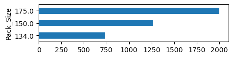

```
========== MIDAGE SINGLES/COUPLES - Mainstream ==========
Pack_Size
134.0    1125
150.0    1858
175.0    2917
Name: count, dtype: int64
```

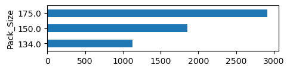

```
========== MIDAGE SINGLES/COUPLES - Budget ==========
Pack_Size
134.0     479
150.0     807
175.0    1217
Name: count, dtype: int64
```

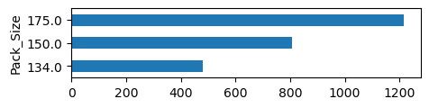

```
========== NEW FAMILIES - Premium ==========
Pack_Size
134.0    151
150.0    272
175.0    393
Name: count, dtype: int64
```

[9 more figures not shown]

```python
for stage in merged_pack["LIFESTAGE"].unique():
 for prem in merged_pack["PREMIUM_CUSTOMER"].unique():
        print('==========',stage, '-', prem,'==========')
        summary = merged_pack[(merged_pack["LIFESTAGE"] == stage) & (merged_pack["PREMIUM_CUSTOMER"] == prem)]["Pack_Size"].value_counts().head(3).sort_index()
        print(summary)
        plt.figure()
        summary.plot.barh(figsize=(5,1))
        plt.show()
```

```python
(temp.groupby(['LIFESTAGE', 'PREMIUM_CUSTOMER'])['PROD_QTY'].sum()/ temp.groupby(["LIFESTAGE", "PREMIUM_CUSTOMER"])["LYLTY_CARD_NBR"].nunique()).sort_values(ascending=False)
```

```
LIFESTAGE               PREMIUM_CUSTOMER
OLDER FAMILIES          Mainstream          9.804309
                        Budget              9.639572
                        Premium             9.578091
YOUNG FAMILIES          Budget              9.238486
                        Premium             9.209207
                        Mainstream          9.180352
OLDER SINGLES/COUPLES   Premium             7.154947
                        Budget              7.145466
                        Mainstream          7.098783
MIDAGE SINGLES/COUPLES  Mainstream          6.796108
RETIREES                Budget              6.458015
                        Premium             6.426653
MIDAGE SINGLES/COUPLES  Premium             6.386672
                        Budget              6.313830
RETIREES                Mainstream          6.253743
NEW FAMILIES            Mainstream          5.087161
                        Premium             5.028912
                        Budget              5.009892
YOUNG SINGLES/COUPLES   Mainstream          4.776459
                        Budget              4.411485
                        Premium             4.402098
dtype: float64
```

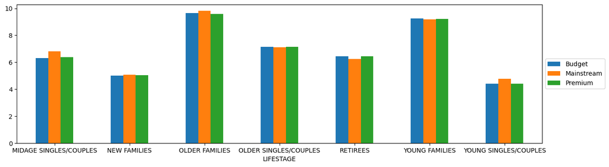

```python
(temp.groupby(["LIFESTAGE", "PREMIUM_CUSTOMER"])["PROD_QTY"].sum() / temp.groupby(["LIFESTAGE", "PREMIUM_CUSTOMER"])["LYLTY_CARD_NBR"].nunique()).unstack().plot.bar(figsize=(15,4), rot=0)
plt.legend(loc="center left", bbox_to_anchor=(1.0, 0.5))
plt.savefig("Average purchase quantity per segment.png", bbox_inches="tight")
```

```python
temp['TOT_SALES'] = pd.to_numeric(temp['TOT_SALES'], errors='coerce')
temp['PROD_QTY'] = pd.to_numeric(temp['PROD_QTY'], errors='coerce')

# Calculate Unit_Price
temp['Unit_Price'] = temp['TOT_SALES'] / temp['PROD_QTY']

# Group by Segment and calculate mean Unit_Price
mean_unit_price = temp.groupby('Segment')['Unit_Price'].mean().sort_values(ascending=False)

print(mean_unit_price)
```

```
Segment
YOUNG SINGLES/COUPLES-Mainstream     4.071485
MIDAGE SINGLES/COUPLES-Mainstream    4.000101
RETIREES-Budget                      3.924883
RETIREES-Premium                     3.921323
NEW FAMILIES-Budget                  3.919251
NEW FAMILIES-Mainstream              3.916581
OLDER SINGLES/COUPLES-Premium        3.887220
OLDER SINGLES/COUPLES-Budget         3.877022
NEW FAMILIES-Premium                 3.871743
RETIREES-Mainstream                  3.833343
OLDER SINGLES/COUPLES-Mainstream     3.803800
YOUNG FAMILIES-Budget                3.753659
MIDAGE SINGLES/COUPLES-Premium       3.752915
YOUNG FAMILIES-Premium               3.752402
OLDER FAMILIES-Budget                3.733344
MIDAGE SINGLES/COUPLES-Budget        3.728496
OLDER FAMILIES-Mainstream            3.727383
YOUNG FAMILIES-Mainstream            3.707097
OLDER FAMILIES-Premium               3.704625
YOUNG SINGLES/COUPLES-Premium        3.645518
YOUNG SINGLES/COUPLES-Budget         3.637681
Name: Unit_Price, dtype: float64
```

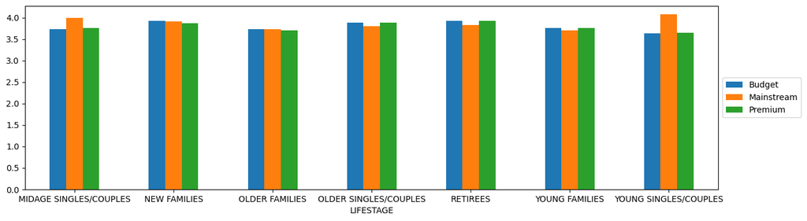

```python
temp['Unit_Price'] = pd.to_numeric(temp['Unit_Price'], errors='coerce')

temp['LIFESTAGE'] = temp['LIFESTAGE'].astype(str)
temp['PREMIUM_CUSTOMER'] = temp['PREMIUM_CUSTOMER'].astype(str)

# Group by 'LIFESTAGE' and 'PREMIUM_CUSTOMER' and calculate the mean of 'Unit_Price'
unit_price_means = temp.groupby(['LIFESTAGE', 'PREMIUM_CUSTOMER'])['Unit_Price'].mean()

#print(unit_price_means)

# Unstack and plot
unit_price_means.unstack().plot.bar(figsize=(15, 4), rot=0)
plt.legend(loc="center left", bbox_to_anchor=(1, 0.5))
plt.show()
```

# Trends and Insights:

**Sales by Segment:**

While ***Young Singles/Couples (Mainstream)*** boasts the largest population within the segments analyzed, their higher total sales likely stem from a larger population size compared to Retirees (Mainstream).

**Purchase Behavior:**

**Spending Patterns:**

The Mainstream category within ***"Young and Midage Singles/Couples"*** emerges as the segment with the highest average spending per chip purchase.

This difference compared to the non-Mainstream ***"Young and Midage Singles/Couples"*** is statistically significant.

**Brand Preferences:**

The *Kettle brand* reigns supreme across all segments, consistently ranking as the most purchased chip brand.

**Chip Size Preference:**

Marketing Recommendations by Customer Segment: Older Families (Budget Segment):

**Maximize Quantity per Purchase:**

**Maximize Reach:** Given their large population size, ensuring our general chip promotions reach this segment frequently is crucial. Utilize marketing channels most frequented by "Young Singles/Couples."

**Retirees (Mainstream Segment):**

Leverage Population Size: Similar to Young Singles/Couples, the **high retiree** population contributes significantly to total sales. Prioritize ensuring our chip promotions reach a broad audience within this segment through appropriate marketing channels.

**General Recommendations:**

Capitalize on Brand & Size Preferences: Across all segments, *Kettle* chips reign supreme, and the *175g* size is the clear favorite, followed by *150g.* Utilize these insights for broader chip promotions by highlighting these popular brands and sizes.